# Project 2C: Galton Data

Sally,Dezi,Zoe

Sunday, April 10, 2022 @ 10:27 PM

## Setup

### Packages Used

```r
library(tidyverse)
library(dplyr)
library(magrittr)
library(ggplot2)
```

### Datasets Used

#### Background of the Data

Francis Galton, a cousin of Charles Darwin, studied the relationship between parent heights and the heights of their offspring. His pioneering [1886 article](https://galton.org/essays/1880-1889/galton-1886-jaigi-regression-stature.pdf) is the first appearance of regression analysis in print. He originated many statistical terms and concepts, including regression, correlation, deviate, quartile, and percentile, plus median for the midpoint of a distribution. The `galtonheightdata` dataset was [created under the direction of Dr. James A. Hanley](http://www.medicine.mcgill.ca/epidemiology/hanley/galton/) using Galton’s [original paper notebooks](http://www.medicine.mcgill.ca/epidemiology/hanley/galton/notebook/index.html) containing the measurement data. You can access the `galtonfamiliesmain.csv` and `galtonfamiliessub.csv` datasets from the [description](https://stat-jet-asu.github.io/Datasets/InstructorDescriptions/galtonheightdata.html) page. A third dataset, `galtonfamiliesnotebook.csv`, shows the notebook page on which each family’s information was recorded.

#### Galton Main Dataset

```r
url <- "https://raw.githubusercontent.com/STAT-JET-ASU/Datasets/master/Instructor/galtonfamiliesmain.csv"
if(!dir.exists("./data/"))
{dir.create("./data/")}
if(!file.exists("./data/galtonfamiliesmain.csv")){
    download.file(url, destfile = "./data/galtonfamiliesmain.csv")}
data_main <- read_csv("./data/galtonfamiliesmain.csv")
glimpse(data_main)
```

```
Rows: 898
Columns: 6
$ FamilyID <chr> "1", "1", "1", "1", "2", "2", "2", "2", "3", "3", "4", "4", "…
$ Children <dbl> 4, 4, 4, 4, 4, 4, 4, 4, 2, 2, 5, 5, 5, 5, 5, 6, 6, 6, 6, 6, 6…
$ Father   <dbl> 78.5, 78.5, 78.5, 78.5, 75.5, 75.5, 75.5, 75.5, 75.0, 75.0, 7…
$ Mother   <dbl> 67.0, 67.0, 67.0, 67.0, 66.5, 66.5, 66.5, 66.5, 64.0, 64.0, 6…
$ Child    <chr> "Son", "Daughter", "Daughter", "Daughter", "Son", "Son", "Dau…
$ Height   <dbl> 73.2, 69.2, 69.0, 69.0, 73.5, 72.5, 65.5, 65.5, 71.0, 68.0, 7…
```

```r
data_main <- data_main %>%
  mutate(
    familyID = as.numeric(ifelse(FamilyID == "136A", 205, FamilyID)),
    motherT = Mother * 1.08,
    midparent = (Father + motherT) / 2,
    heightT = ifelse(Child == "Daughter", Height * 1.08, Height)
  ) %>%
  select(
    familyID,
    child_num = Children,
    father = Father,
    mother = Mother,
    motherT,
    midparent,
    child_gen = Child,
    height = Height,
    heightT
  ) %>%
  arrange(
    familyID,
    desc(child_gen),
    desc(height)
  )
glimpse(data_main)
```

```
Rows: 898
Columns: 9
$ familyID  <dbl> 1, 1, 1, 1, 2, 2, 2, 2, 3, 3, 4, 4, 4, 4, 4, 5, 5, 5, 5, 5, …
$ child_num <dbl> 4, 4, 4, 4, 4, 4, 4, 4, 2, 2, 5, 5, 5, 5, 5, 6, 6, 6, 6, 6, …
$ father    <dbl> 78.5, 78.5, 78.5, 78.5, 75.5, 75.5, 75.5, 75.5, 75.0, 75.0, …
$ mother    <dbl> 67.0, 67.0, 67.0, 67.0, 66.5, 66.5, 66.5, 66.5, 64.0, 64.0, …
$ motherT   <dbl> 72.36, 72.36, 72.36, 72.36, 71.82, 71.82, 71.82, 71.82, 69.1…
$ midparent <dbl> 75.43, 75.43, 75.43, 75.43, 73.66, 73.66, 73.66, 73.66, 72.0…
$ child_gen <chr> "Son", "Daughter", "Daughter", "Daughter", "Son", "Son", "Da…
$ height    <dbl> 73.2, 69.2, 69.0, 69.0, 73.5, 72.5, 65.5, 65.5, 71.0, 68.0, …
$ heightT   <dbl> 73.200, 74.736, 74.520, 74.520, 73.500, 72.500, 70.740, 70.7…
```

#### Galton Subset Dataset

```r
url <- "https://raw.githubusercontent.com/STAT-JET-ASU/Datasets/master/Instructor/galtonfamiliessub.csv"
if(!dir.exists("./data/"))
{dir.create("./data/")}
if(!file.exists("./data/galtonfamiliessub.csv")){
    download.file(url, destfile = "./data/galtonfamiliessub.csv")}
data_sub <- read_csv("./data/galtonfamiliessub.csv")
glimpse(data_sub)
```

```
Rows: 36
Columns: 6
$ FamilyID <dbl> 13, 13, 50, 50, 84, 84, 84, 84, 84, 111, 120, 120, 120, 120, …
$ Children <dbl> 2, 2, 2, 2, 4, 4, 4, 4, 4, 1, 11, 11, 11, 11, 11, 11, 11, 11,…
$ FatherR  <dbl> 13.0, 13.0, 11.0, 11.0, 10.5, 10.5, 10.5, 10.5, 10.5, 9.0, 9.…
$ MotherR  <dbl> 7.0, 7.0, 5.4, 5.4, 3.0, 3.0, 3.0, 3.0, 3.0, 3.5, 2.0, 2.0, 2…
$ Child    <chr> "Son", "Daughter", "Son", "Daughter", "Son", "Son", "Son", "D…
$ HeightR  <dbl> 11.0, 2.0, 13.0, 2.0, 10.0, 8.5, 5.5, 5.5, 3.5, 5.5, 12.0, 10…
```

```r
data_sub <- data_sub %>%
  mutate(
    father = FatherR + 60,
    mother = MotherR + 60,
    motherT = mother * 1.08,
    midparent = (father + motherT) / 2,
    height = HeightR + 60,
    heightT = ifelse(Child == "Daughter", height * 1.08, height)
  ) %>%
  select(
    familyID = FamilyID,
    child_num = Children,
    father,
    mother,
    motherT,
    midparent,
    child_gen = Child,
    height,
    heightT
  ) %>%
  arrange(
    familyID,
    desc(child_gen),
    desc(height)
  )
glimpse(data_sub)
```

```
Rows: 36
Columns: 9
$ familyID  <dbl> 13, 13, 50, 50, 84, 84, 84, 84, 84, 111, 120, 120, 120, 120,…
$ child_num <dbl> 2, 2, 2, 2, 4, 4, 4, 4, 4, 1, 11, 11, 11, 11, 11, 11, 11, 11…
$ father    <dbl> 73.0, 73.0, 71.0, 71.0, 70.5, 70.5, 70.5, 70.5, 70.5, 69.0, …
$ mother    <dbl> 67.0, 67.0, 65.4, 65.4, 63.0, 63.0, 63.0, 63.0, 63.0, 63.5, …
$ motherT   <dbl> 72.360, 72.360, 70.632, 70.632, 68.040, 68.040, 68.040, 68.0…
$ midparent <dbl> 72.680, 72.680, 70.816, 70.816, 69.270, 69.270, 69.270, 69.2…
$ child_gen <chr> "Son", "Daughter", "Son", "Daughter", "Son", "Son", "Son", "…
$ height    <dbl> 71.0, 62.0, 73.0, 62.0, 70.0, 68.5, 65.5, 65.5, 63.5, 65.5, …
$ heightT   <dbl> 71.000, 66.960, 73.000, 66.960, 70.000, 68.500, 65.500, 70.7…
```

#### Galton Notebook Dataset

```r
## Loads the data from galtonfamiliesnotebook and names the dataset data_ntbk

data_ntbk <- read_csv("https://raw.githubusercontent.com/STAT-JET-ASU/Datasets/master/Instructor/galtonfamiliesnotebook.csv")

#Displays the contents of data_ntbk

glimpse(data_ntbk)
```

```
Rows: 205
Columns: 2
$ FamilyID <chr> "1", "2", "3", "4", "5", "6", "7", "8", "9", "10", "11", "12"…
$ Page     <dbl> 1, 1, 1, 1, 1, 1, 1, 1, 1, 1, 1, 1, 1, 1, 1, 1, 1, 1, 1, 1, 1…
```

```r
data_ntbk <- data_ntbk %>%

#Mutate the notebook data (change familyID just like in main dataset)

mutate(familyID = as.numeric(ifelse(FamilyID == "136A", 205, FamilyID)))
```

## Analyses

### Create the Analysis Datasets

#### Dataset #1

Load the three Galton datasets and use `glimpse()` to explore their structures. Refer to Project 1 and use the new data binding/joining skills you have learned to assemble a single dataset that meets the following criteria. Use `glimpse()` and `head()` to display the result. (Hint: Use `bind_rows()` to connect the `main` and `sub` datasets, then use a join to add the `notebook` information.)

- contains these variables:
  - `familyid` = ID number of the family, with `136A` recoded as `205`
  - `page` = the notebook page on which the family is recorded
  - `num_children`= the number of children in the family
  - `father_ht` = the height of the father
  - `mother_ht` = the “transmuted” (per Galton) height of the mother
  - `midparent` = the average of the parents’ heights (using transmuted mother)
  - `child_sex`= whether the child is a son or a daughter, in all lower case
  - `child_ht` = the height of the child with daughter heights “transmuted”
- is arranged according to:
  - ascending order of familyid
  - sons before daughters within family
  - in order of height within each sex of child

```r
bind_rows(data_main, data_sub) -> data_new
merge(x=data_new, y=data_ntbk, by="familyID") %>%
  arrange(familyID,
          factor(child_gen, levels=c('Son','Daugter')),
          height) -> data_all
glimpse(data_all)
```

```
Rows: 934
Columns: 11
$ familyID  <dbl> 1, 1, 1, 1, 2, 2, 2, 2, 3, 3, 4, 4, 4, 4, 4, 5, 5, 5, 5, 5, …
$ child_num <dbl> 4, 4, 4, 4, 4, 4, 4, 4, 2, 2, 5, 5, 5, 5, 5, 6, 6, 6, 6, 6, …
$ father    <dbl> 78.5, 78.5, 78.5, 78.5, 75.5, 75.5, 75.5, 75.5, 75.0, 75.0, …
$ mother    <dbl> 67.0, 67.0, 67.0, 67.0, 66.5, 66.5, 66.5, 66.5, 64.0, 64.0, …
$ motherT   <dbl> 72.36, 72.36, 72.36, 72.36, 71.82, 71.82, 71.82, 71.82, 69.1…
$ midparent <dbl> 75.43, 75.43, 75.43, 75.43, 73.66, 73.66, 73.66, 73.66, 72.0…
$ child_gen <chr> "Son", "Daughter", "Daughter", "Daughter", "Son", "Son", "Da…
$ height    <dbl> 73.2, 69.0, 69.0, 69.2, 72.5, 73.5, 65.5, 65.5, 71.0, 68.0, …
$ heightT   <dbl> 73.200, 74.520, 74.520, 74.736, 72.500, 73.500, 70.740, 70.7…
$ FamilyID  <chr> "1", "1", "1", "1", "2", "2", "2", "2", "3", "3", "4", "4", …
$ Page      <dbl> 1, 1, 1, 1, 1, 1, 1, 1, 1, 1, 1, 1, 1, 1, 1, 1, 1, 1, 1, 1, …
```

#### Dataset #2

From Dataset #1, select the variables `familyid` and `num_children`, then reduce the dataset so it contains only one unique row per family. Use `glimpse()` to display the result. (Hint: The final dataset should have 205 rows/observations and two variables/columns.)

```r
dataset_2 <- data_all %>%

  select(familyid = familyID,

         num_children = child_num) %>%

  distinct()

## Use `glimpse()` to display the result. (Hint: The final dataset should have 205 rows/observations and two variables/columns.)

glimpse(dataset_2)
```

```
Rows: 205
Columns: 2
$ familyid     <dbl> 1, 2, 3, 4, 5, 6, 7, 8, 9, 10, 11, 12, 13, 14, 15, 16, 17…
$ num_children <dbl> 4, 4, 2, 5, 6, 1, 6, 3, 1, 1, 8, 1, 2, 2, 3, 9, 6, 3, 1, …
```

### Visualization 1: Updated Scatterplot

#### Galton’s Visualization

In his original paper (linked above), Galton created several tables and diagrams. His “Diagram Based on Table 1” of them is similar in concept to a scatterplot. Rather than dots, he grouped/tabulated the data, and then used the count of how many people were grouped at the coordinate pairs in his grid, with child as the x-axis and mid-parent as the y-axis. There are two scales: inches and deviations from 68.25 inches.


#### Your Data Visualization

**This plot uses Dataset #1.**

Create a scatterplot of child height (x-axis) versus mid-parent height (y-axis). Ordinarily, we might reverse the axes here because analysts would be more likely to model child height as a function of parent height, but we want to be able to compare the updated plot to Galton’s original.

Include the following.

- make your dots larger than the default size to help show density
- set transparency to adjust for overplotting and help show density
- use `color =` in the `aes` to differentiate sons versus daughters
- use `scale_color_manual()` to choose two colorblind-safe colors
- scale both axes so that there is a tick mark at every whole inch
- use `coord_fixed()` so that the axes have the same unit spacing
- add better x- and y-axis labels, including the units of measure
- add an informative title (you may optionally include a subtitle)
- add `color =` to `labs()` to set the legend title to `"gender of child"`
- use a built-in theme (e.g., `theme_linedraw()`) to add formatting
- use `theme()` to move the legend to the bottom of the scatterplot

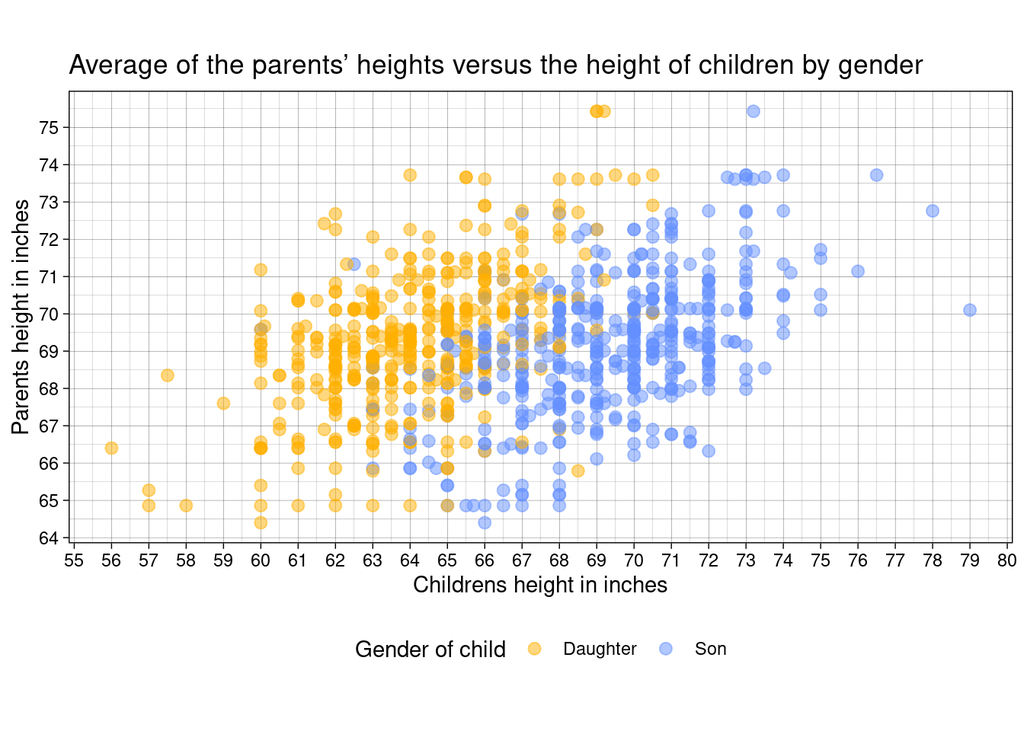

```r
p1 <- ggplot(data_all, aes(x=height, y=midparent, color=child_gen)) +
  geom_point(alpha=.50, size=2.5) +
  scale_color_manual(values = c("#FFB000","#648FFF")) +
  scale_x_continuous(breaks= 55:80) +
  scale_y_continuous(breaks= 64:76) +
  coord_fixed() +
  labs(color = "Gender of child", title = "Average of the parents’ heights versus the height of children by gender", x = "Childrens height in inches", y="Parents height in inches") +
  theme_linedraw()
p1 + theme(legend.position = "bottom")
```

### Visualization 2: Number of Children

**This plot uses Dataset #2.**

Create a barplot to show the distribution of the number of children per family. Set the bars to something other than the default `width`. Scale the x-axis so that there is a tick mark for each bar. Choose appropriate colors, labels, themes, and/or and other types of formatting that you feel will enhance the meaning or visual appearance of the plot. (Hint: Use `count()` to find out how many families have a given number of children, then use that information to create your plot.)

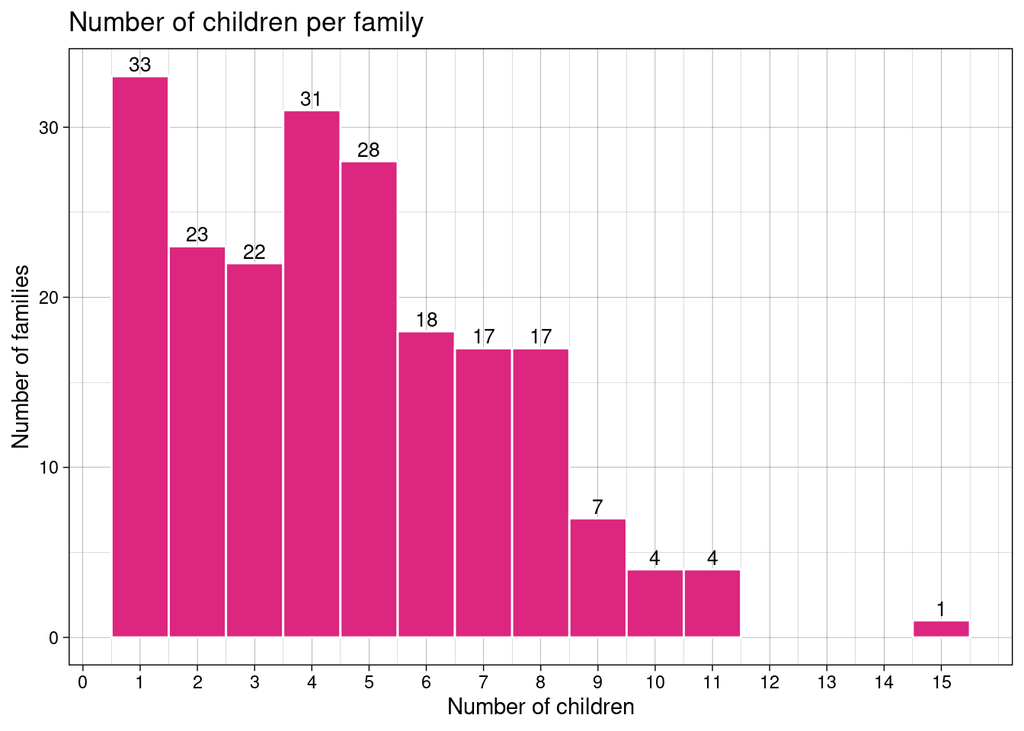

```r
ggplot(dataset_2, aes(num_children)) +
  geom_bar(width = 1, color = "white", fill = "#DC267F") +
  scale_x_continuous(breaks= 0:15) +
  labs(title = "Number of children per family", x = "Number of children", y="Number of families") +
  geom_text(aes(label = ..count..), stat = "count", vjust = -.3, size = 3.5) +
  theme_linedraw()
```

## Questions

**Question 1:** Do you think your scatterplot is an improvement over Galton’s original diagram? Are there any other modifications and/or additions you would make to enhance the clarity or usefulness of your plot?

**ANSWER**

I feel that our updated scatterplot is an improvement to Galton’s original diagram beacuse it is visually cleaner. Something that I think would be interesting to add would be a regression line to see how strong of a correlation there is between the two heights.

**Question 2:** Explain the rationale behind the choices you made when creating your scatterplot and barplot, such as size, color, transparency, or other features. What motivated your decisions?

**ANSWER**

**Question 3:** Considering best practices, how does using `coord_fixed()` enhance the authenticity of the information shown in the scatterplot, such as the relationship and spread of the data?

**ANSWER**

Using `coord_fixed()` helps insure that the spread has not been stretched out or shrunk so that we can more easily see the correlation.